# My Thesis

Drew Heasman

Abstract

This is a sample thesis that we’re using to showcase some practical applications of integrated documents.

# Our Sample Thesis

## Knitting your Thesis

Open this `Rmd` file in RMarkdown. It should all be ready to go, to turn it into a cool `HTML` document. To do that, look at the RStudio toolbar and click the `knit` button.

You can also knit (or render) your RMarkdown documents using the command line. There are good reasons for doing this, and cool tricks you can try (see the Tips & Tricks later in the workshop). To do that, go to the folder that your RMarkdown document is in and type in the command:

```
Rscript -e "rmarkdown::render('filename.Rmd')"
```

No need to try it here, but just wanted to mention it :)

## Integrating Code

When you’re working on your thesis you’re probably loading some data, and then doing some analysis. We’re going to show a couple ways of doing it, but we’re also going to look at how to integrate that code directly into your text.

### Data Import

We did some work looking at Github repositories earlier, and added information to a Google spreadsheet. I’ve downloaded the data into a CSV file in the `data/input` directory of this project.

```r
library(assertthat)
table <- read.csv('data/input/GitHubRepositories.csv')
```

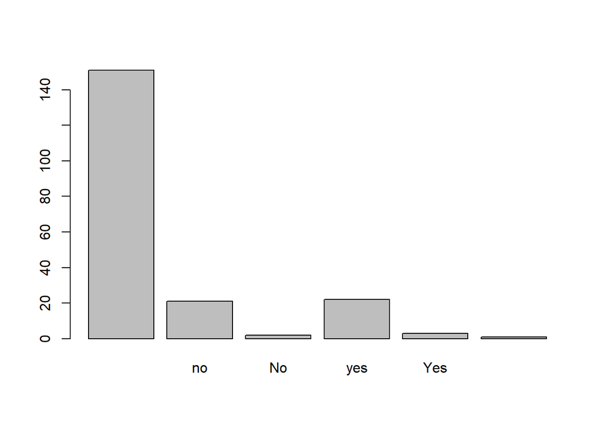

```r
plot(factor(table[,3]))
```

### Dynamic Data

Sometimes we’re working with data that comes from the World Wide Web. The Internet is basically a series of tubes. Some research databases or online tools have packages that allow you to obtain data directly through in internet connection. [xDeepDive](http://geodeepdive.org) is a tool that has harvested full text from hundreds of thousands of journal publications. We can connect to it using a URL:

```
https://geodeepdive.org/api/
```

```r
library(jsonlite)
climate <- jsonlite::fromJSON('https://geodeepdive.org/api/snippets?term=logic&clean&full_results')
```

# Templates

Most universities and departments make a Word or latex template available for theses. For example, the template in the `templates` folder is provided by [Simon Fraser University](https://www.lib.sfu.ca/help/publish/thesis/templates).

# Bibliography

Pandoc (and by extension, RMarkdown) can support the use of a bibliography in [Bibtex format](http://www.bibtex.org/). These references can be rendered into a number of different formats using an XML-type file called the [Citation Style Language](https://citationstyles.org/), or CSL. These files define how the reference is rendered and referenced in text. You can see a full list of available formats (for a large number of journals) in the [CSL Github styles repository](https://github.com/citation-style-language/styles).

If I wanted to cite a paper, for example, the winner of an IgNobel prize for making feces knives (Eren et al. 2019), I could simply add an in text citation to my bibliography file. We’ll edit this further once we get used to using `git` workflows.

There’s some great information about [using RMarkdown citations & bibliographies](https://rmarkdown.rstudio.com/authoring_bibliographies_and_citations.html) on the RStudio website.

# References

Eren, Metin I, Michelle R Bebber, James D Norris, Alyssa Perrone, Ashley Rutkoski, Michael Wilson, and Mary Ann Raghanti. 2019. “Experimental Replication Shows Knives Manufactured from Frozen Human Feces Do Not Work.” *Journal of Archaeological Science: Reports* 27: 102002.